# IODS course project

Jetro Anttonen

# Introduction to Open Data Science - Course Project

# Chapter 1

*Here I am writing a short description about the course (Or perhaps more like a few thoughts about the course). I include a link to my GitHub repository here as well. This is an R Markdown (.Rmd) file so I’ll be using R Markdown syntax.*

The R chunck below prints out the date and time at the time of knitting this Markdown document for no particular reason.

```r
# This is a so-called "R chunk" where I can write my R code.

date()
```

```
## [1] "Thu Nov 24 13:33:12 2022"
```

Okay, so I’m feeling great and on this course I expect to learn all kinds of both interesting and useful things about Github, Markdown and reproducible research in general. Also, I learned about the course from Sisu when looking for useful and interesting courses among the ones listed suitable for my PhD degree (that is, there is a list of courses from which one needs to choose at least 10 study points in order to complete one’s degree).

I was pretty familiar already with the material covered in ‘R for Health Data Science book’ and in the ‘Exercise Set 1’, since I have a strong background in both statistics/data science and in R. However, I’m motivated to learn as many new tools as possible to make my research as open and reproducible as possible. I also wish to learn ways to streamline my research workflows by more fluent integration of coding, writing and publishing via Github, Markdown and R-studio.

Last but not the least, here is a link to my Github repository used during the course: [My Github Repo](https://github.com/jetroant/IODS-project)

# Chapter 2

```r
students2014 <- read.csv("./data/learning2014.csv")
str(students2014)
```

```
## 'data.frame':    166 obs. of  7 variables:
##  $ gender  : chr  "F" "M" "F" "M" ...
##  $ age     : int  53 55 49 53 49 38 50 37 37 42 ...
##  $ attitude: num  3.7 3.1 2.5 3.5 3.7 3.8 3.5 2.9 3.8 2.1 ...
##  $ deep    : num  3.58 2.92 3.5 3.5 3.67 ...
##  $ stra    : num  3.38 2.75 3.62 3.12 3.62 ...
##  $ surf    : num  2.58 3.17 2.25 2.25 2.83 ...
##  $ points  : int  25 12 24 10 22 21 21 31 24 26 ...
```

Above we have loaded the dataset to be used for this week’s assignment and printed a short summary of the data. The data consists of:  
2 variables of type ‘int’ (age, points),  
4 variables of type ‘num’ (attitude, deep, stra, surf), and  
1 variables of type ‘character’ (gender).

Also, there are 166 observations per variable and in the data are results from a survey with originally 183 respondents. Respondents were course participants and those with zero exam points from the course exam were removed from the data. The variables `deep`, `stra` and `surf` are aggregate variables constructed from multiple responses. More information on the dataset is available [here](https://www.mv.helsinki.fi/home/kvehkala/JYTmooc/JYTOPKYS3-meta.txt).

Below are marginal distributions for every variable in the data, except for the variable `gender`, which is a binary variable for which 66% respondents answered `F` and 34% respondents answered `M`.

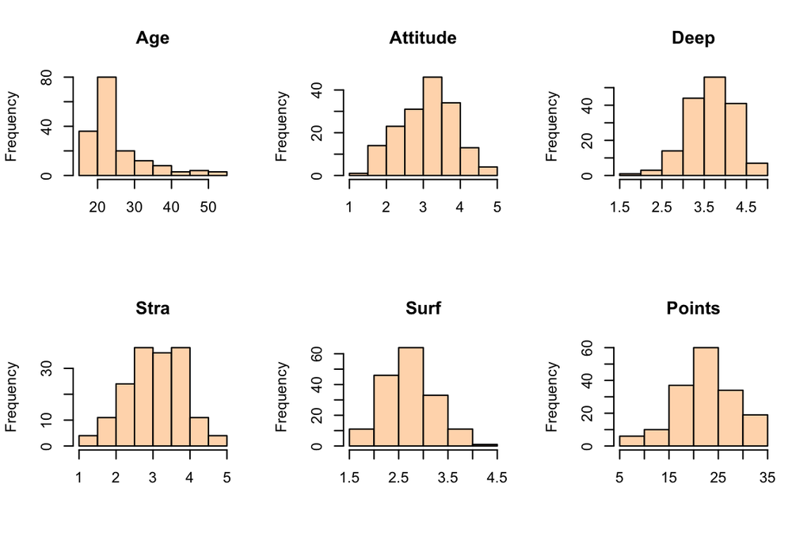

While marginal distributions are useful in assessing the shape of the distribution of individual variables, we may use `pairs` to draw scatter plots summarizing the pairwise dependencies between different variables.

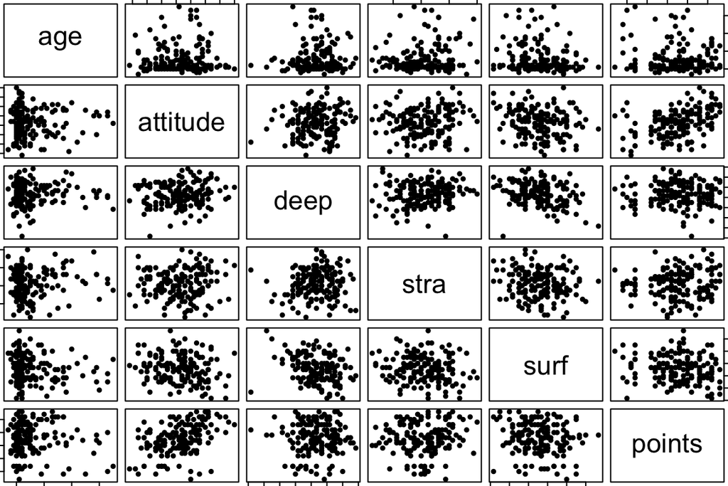

Based on quick visual assessment, there might be at least some positive correlation between `points` and `attitude`. Much of the dependencies are however not clear enough, but can be be a little difficult to read from the pairwise scatter plots. To this end we may also inspect the correlation matrix of the data (below).

```
##                 age attitude  deep  stra  surf points gender_binary
## age            1.00     0.02  0.03  0.10 -0.14  -0.09         -0.12
## attitude       0.02     1.00  0.11  0.06 -0.18   0.44         -0.29
## deep           0.03     0.11  1.00  0.10 -0.32  -0.01         -0.06
## stra           0.10     0.06  0.10  1.00 -0.16   0.15          0.15
## surf          -0.14    -0.18 -0.32 -0.16  1.00  -0.14          0.11
## points        -0.09     0.44 -0.01  0.15 -0.14   1.00         -0.09
## gender_binary -0.12    -0.29 -0.06  0.15  0.11  -0.09          1.00
```

Above we have created coded the variable `gender` as to a binary variable which gets values equal to one if `gender = F` and otherwise zero. The correlation between points and attitude is the strongest linear dependency, as our visual assessment already suggested.

We shall take take the three variables with the largest absolute correlations with `points` as our starting point for the analysis. That is, we estimate a linear regression model with `points` as the dependent variables and three explanatory variables (`attitude`, `stra` and `surf`). The results of our regression model are summarized below (standard errors are not heteroskedasticity robust).

```r
model1 <- lm(points ~ attitude + stra + surf, data = students2014)
summary(model1)
```

```
##
## Call:
## lm(formula = points ~ attitude + stra + surf, data = students2014)
##
## Residuals:
##      Min       1Q   Median       3Q      Max
## -17.1550  -3.4346   0.5156   3.6401  10.8952
##
## Coefficients:
##             Estimate Std. Error t value Pr(>|t|)
## (Intercept)  11.0171     3.6837   2.991  0.00322 **
## attitude      3.3952     0.5741   5.913 1.93e-08 ***
## stra          0.8531     0.5416   1.575  0.11716
## surf         -0.5861     0.8014  -0.731  0.46563
## ---
## Signif. codes:  0 '***' 0.001 '**' 0.01 '*' 0.05 '.' 0.1 ' ' 1
##
## Residual standard error: 5.296 on 162 degrees of freedom
## Multiple R-squared:  0.2074, Adjusted R-squared:  0.1927
## F-statistic: 14.13 on 3 and 162 DF,  p-value: 3.156e-08
```

Above reported t-test statistics suggest that the coefficients for `stra` and `surf` are not statistically significant from zero, as already suggested by low absolute correlations between them and `points`. To elaborate, t-test tests the null hypothesis `coefficient = 0` for every variable in the model and only the coefficient on `attitude` was found to be statistically significant (and clearly so!).

To that end, we drop both `stra` and `surf` from our regression and run the final model with `attitude` as the only explanatory variable.

```r
model2 <- lm(points ~ attitude, data = students2014)
summary(model2)
```

```
##
## Call:
## lm(formula = points ~ attitude, data = students2014)
##
## Residuals:
##      Min       1Q   Median       3Q      Max
## -16.9763  -3.2119   0.4339   4.1534  10.6645
##
## Coefficients:
##             Estimate Std. Error t value Pr(>|t|)
## (Intercept)  11.6372     1.8303   6.358 1.95e-09 ***
## attitude      3.5255     0.5674   6.214 4.12e-09 ***
## ---
## Signif. codes:  0 '***' 0.001 '**' 0.01 '*' 0.05 '.' 0.1 ' ' 1
##
## Residual standard error: 5.32 on 164 degrees of freedom
## Multiple R-squared:  0.1906, Adjusted R-squared:  0.1856
## F-statistic: 38.61 on 1 and 164 DF,  p-value: 4.119e-09
```

The intercept of the final model is estimated to be 11.64, which can be interpreted as the model predicting exam points to be that much on average for someone with `attitude = 0`. On the other hand, the more interesting coefficient on `attitude` is estimated to be 3.53, which suggests that on average, every additional point in `attitude` raises (or is associated with) 3.53 point rise in exam points. The multiple R-squared for the model is around 19%, suggesting the lone explanatory model to explain that much of the variance of the model (or variation in the dependent variable `points`).

Next, we shall take a look at some visual model diagnostics and discuss a little about the assumptions of our model. Let’s see the visual diagnostics first.

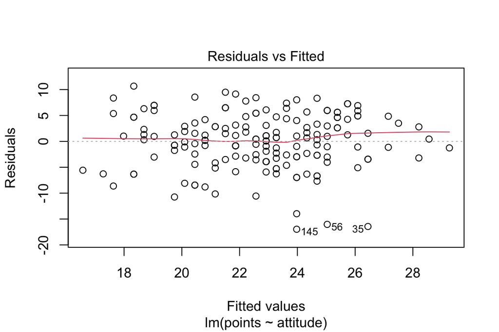

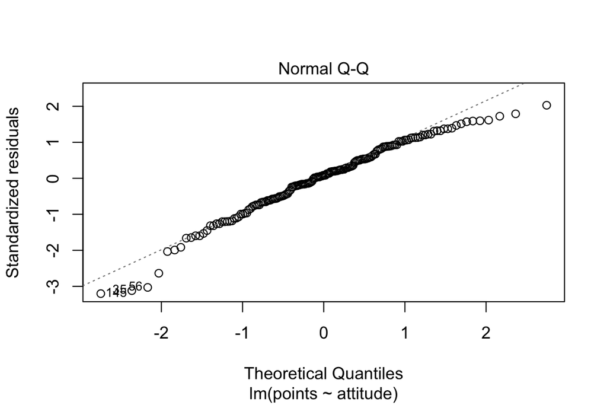

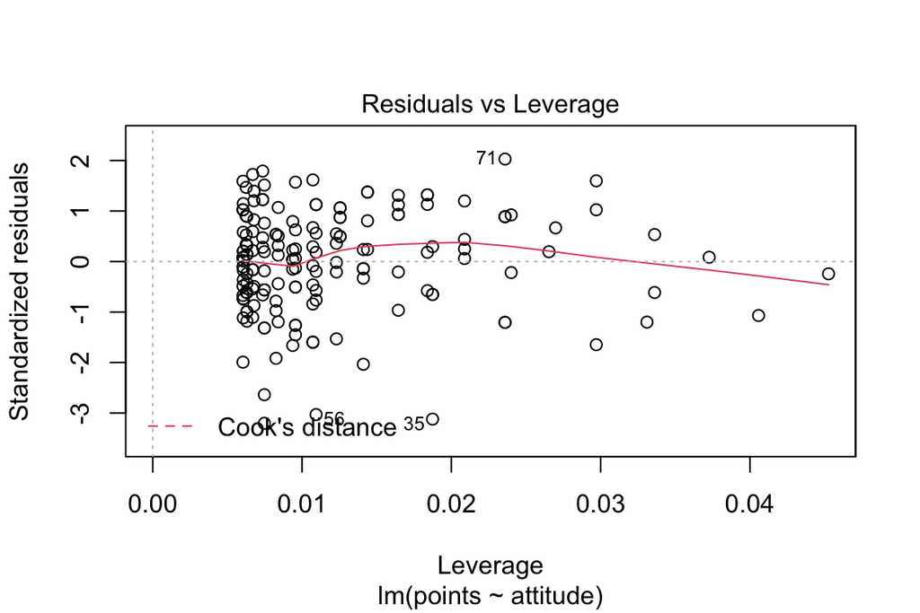

[figure not shown]

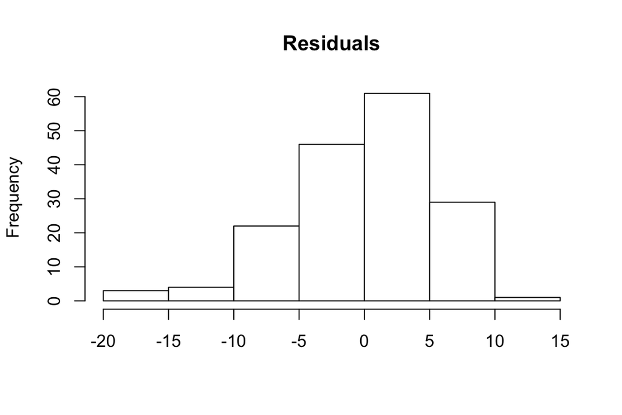

Above we have plotted Residuals vs Fitted values, Normal QQ-plot, Residuals vs Leverage, `points` against `attitude` with our linear regression line going over the scatter plot and finally a histogram of the residuals. First, as both Normal QQ-plot and the histogram of residuals suggests, the residuals of the model are slightly skewed, left tail being thicker than normal, but right tail thinner. That is, residuals do not look normally distributed. Moreover, there does not seem to be too wild outliers in the data, nor are the results dominated by particular observations as suggested by relatively low maximum leverage. The residuals seem also quite homoskedastic (although debatable and probably heteroskedasticity ribust standard errors should be used just in case).

Fortunately linear regression model does not require for us to assume to residuals to be normally distributed. Technically, it only needs to be assumed that the residuals have well defined fourth moments (and in this case homoskedastic). Our coefficient estimates and estimates for their standard deviation will be asymptotically correct. Also we may safely assume the residuals based on survey based data to be uncorrelated with each other. The dependence between `points` and `attitude`also seems fairly linear, as required by our model assumptions.

Thus, our model assumptions seem relatively well justified.

# Chapter 3

```r
alc <- read.csv("./data/alc.csv")
str(alc)
```

```
## 'data.frame':    370 obs. of  35 variables:
##  $ school    : chr  "GP" "GP" "GP" "GP" ...
##  $ sex       : chr  "F" "F" "F" "F" ...
##  $ age       : int  15 15 15 15 15 15 15 15 15 15 ...
##  $ address   : chr  "R" "R" "R" "R" ...
##  $ famsize   : chr  "GT3" "GT3" "GT3" "GT3" ...
##  $ Pstatus   : chr  "T" "T" "T" "T" ...
##  $ Medu      : int  1 1 2 2 3 3 3 2 3 3 ...
##  $ Fedu      : int  1 1 2 4 3 4 4 2 1 3 ...
##  $ Mjob      : chr  "at_home" "other" "at_home" "services" ...
##  $ Fjob      : chr  "other" "other" "other" "health" ...
##  $ reason    : chr  "home" "reputation" "reputation" "course" ...
##  $ guardian  : chr  "mother" "mother" "mother" "mother" ...
##  $ traveltime: int  2 1 1 1 2 1 2 2 2 1 ...
##  $ studytime : int  4 2 1 3 3 3 3 2 4 4 ...
```

[output cut: 21 more lines]

Above we have printed some information of the data to be used in this week’s assignment, including variable names as well as data types of the variables. In total we have 370 observations and 35 variables. The data are student level results from a questionnaire in two Portuguese schools (secondary education) and the variables measure student achievement as well as demographic and social features. Based on this data, we shall study the relationship between alcohol consumption and some of the variables.

Of other variables than those related to alcohol consumption, we shall focus our attention on `higher`, `romantic`, `famrel` and `G3` (final grade). The working hypothesis is that the variables measuring social aspects (`romantic` and `famrel`) could be negatively correlated with alcohol consumption, whereas the variables related to ambitions and achievement (`higher` and `G3`) could as well be negatively associated with alcohol consumption, since excessive alcohol could make it more difficult to succeed in school.

For the analysis we need to encode `romantic` and `higher` (both take character values `yes` or `no`) to a binary variables taking values 1 and zero.

```r
alc$romantic_binary <- ifelse(alc$romantic == "yes", 1, 0)
alc$higher_binary <- ifelse(alc$higher == "yes", 1, 0)
```

Below we see the marginal distributions of the four explanatory variables for both `high_use = TRUE` and `high_use = FALSE`. Variable `high_use` takes values `TRUE` if the weekly alcohol consumption exceeds a certain threshold. For 30% of the students in the sample `high_use = TRUE`.

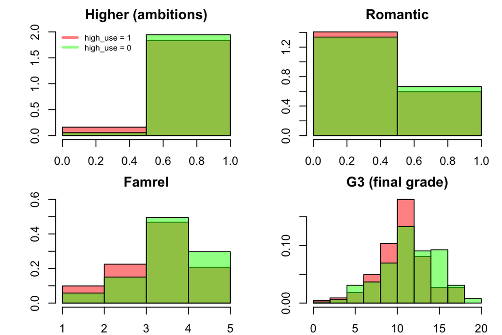

[output not shown]

As for the next variable, whether student is in a romantic relationship does not seem to have much effect on one’s alcohol consumption. However, `high_use = TRUE` seems to be slightly more common for `romantic = “no”`, as hypothesized. Good family relations (higher values of `famrel`) on the other hand seem to be clearly associated with less alcohol consumption, also as hypothesized. Finally, perhaps the most clear negative association (by visual inspection at least) is between high alcohol consumption and final grade, or educational success, which makes perfect sense, and is also as we suspected.

Next, we shall estimate a logistic regression model using the four just discussed variables as explanatory variables and `high_use` as the dependent variable. Below we have printed out the summary of our results.

```r
# Logistic regression model
model <- glm(high_use ~ higher_binary + romantic_binary + famrel + G3,
             data = alc, family = binomial(link = "logit"))

# A summary of the estimated model
summary(model)
```

```
##
## Call:
## glm(formula = high_use ~ higher_binary + romantic_binary + famrel +
##     G3, family = binomial(link = "logit"), data = alc)
##
## Deviance Residuals:
##     Min       1Q   Median       3Q      Max
## -1.4342  -0.8506  -0.7251   1.3382   1.9521
##
## Coefficients:
##                 Estimate Std. Error z value Pr(>|z|)
## (Intercept)      2.06805    0.77766   2.659  0.00783 **
## higher_binary   -0.90841    0.55444  -1.638  0.10133
## romantic_binary -0.33272    0.25738  -1.293  0.19611
## famrel          -0.28414    0.12473  -2.278  0.02272 *
## G3              -0.07423    0.03716  -1.997  0.04578 *
## ---
## Signif. codes:  0 '***' 0.001 '**' 0.01 '*' 0.05 '.' 0.1 ' ' 1
##
## (Dispersion parameter for binomial family taken to be 1)
##
##     Null deviance: 452.04  on 369  degrees of freedom
## Residual deviance: 436.57  on 365  degrees of freedom
## AIC: 446.57
##
## Number of Fisher Scoring iterations: 4
```

```r
# Odds ratios
odds_ratios <- exp(model$coefficients)

# Confidence intervals
ci <- confint(model)
# Printing out both odds ratios and their confidence intervals
print(cbind(odds_ratios, exp(ci)))
```

```
##                 odds_ratios     2.5 %     97.5 %
## (Intercept)       7.9093629 1.7560948 37.6713039
## higher_binary     0.4031642 0.1315342  1.1948265
## romantic_binary   0.7169700 0.4283564  1.1778900
## famrel            0.7526588 0.5885479  0.9614471
## G3                0.9284590 0.8625985  0.9983319
```

On the other hand, the coefficients on `famrel` and `G3` were found to be statistically significant on a 95% level, albeit small-ish in absolute value. Based on these findings, we could say the data and the model to give some support to our hypothesis of both healthy social relations and educational ambitions to be negatively associated with high alcohol consumption.

```
##         prediction
## high_use   0   1
##        0 249  10
##        1 105   6
```

Clearly, the model inaccurately classifies almost all of the students as `high_use = 0`. This is no surprise, since for 70% of the students this is indeed the case, thus by classifying every student like this, one would already obtain a respectable (not really) accuracy rate of 70%.

So does our model perform any better than such a simple guessing strategy? Unfortunately it turns out not to be the case… The accuracy rate of our model is only 68.92% (31.08% training error) against the 70% (30% training error) of the simple guessing strategy.

To conclude, the predictive performance of our model is poor, reflecting the weakness of our obtained results. However, the data and the model do give some support to our hypothesis of both healthy social relations and educational ambitions to be negatively associated with high alcohol consumption.

# Chapter 4

```r
library(MASS)
data("Boston")
str(Boston)
```

```
## 'data.frame':    506 obs. of  14 variables:
##  $ crim   : num  0.00632 0.02731 0.02729 0.03237 0.06905 ...
##  $ zn     : num  18 0 0 0 0 0 12.5 12.5 12.5 12.5 ...
##  $ indus  : num  2.31 7.07 7.07 2.18 2.18 2.18 7.87 7.87 7.87 7.87 ...
##  $ chas   : int  0 0 0 0 0 0 0 0 0 0 ...
##  $ nox    : num  0.538 0.469 0.469 0.458 0.458 0.458 0.524 0.524 0.524 0.524 ...
##  $ rm     : num  6.58 6.42 7.18 7 7.15 ...
##  $ age    : num  65.2 78.9 61.1 45.8 54.2 58.7 66.6 96.1 100 85.9 ...
##  $ dis    : num  4.09 4.97 4.97 6.06 6.06 ...
##  $ rad    : int  1 2 2 3 3 3 5 5 5 5 ...
##  $ tax    : num  296 242 242 222 222 222 311 311 311 311 ...
##  $ ptratio: num  15.3 17.8 17.8 18.7 18.7 18.7 15.2 15.2 15.2 15.2 ...
##  $ black  : num  397 397 393 395 397 ...
##  $ lstat  : num  4.98 9.14 4.03 2.94 5.33 ...
##  $ medv   : num  24 21.6 34.7 33.4 36.2 28.7 22.9 27.1 16.5 18.9 ...
```

Above we have loaded a dataset called `Boston` from the `MASS` package. The dataset consists of crime rates in various towns in Boston area, along with various other town characteristics. In total there are 506 observations (towns) and 14 variables.

Below are the marginal distributions as well as pair plots of all the variables in the data.

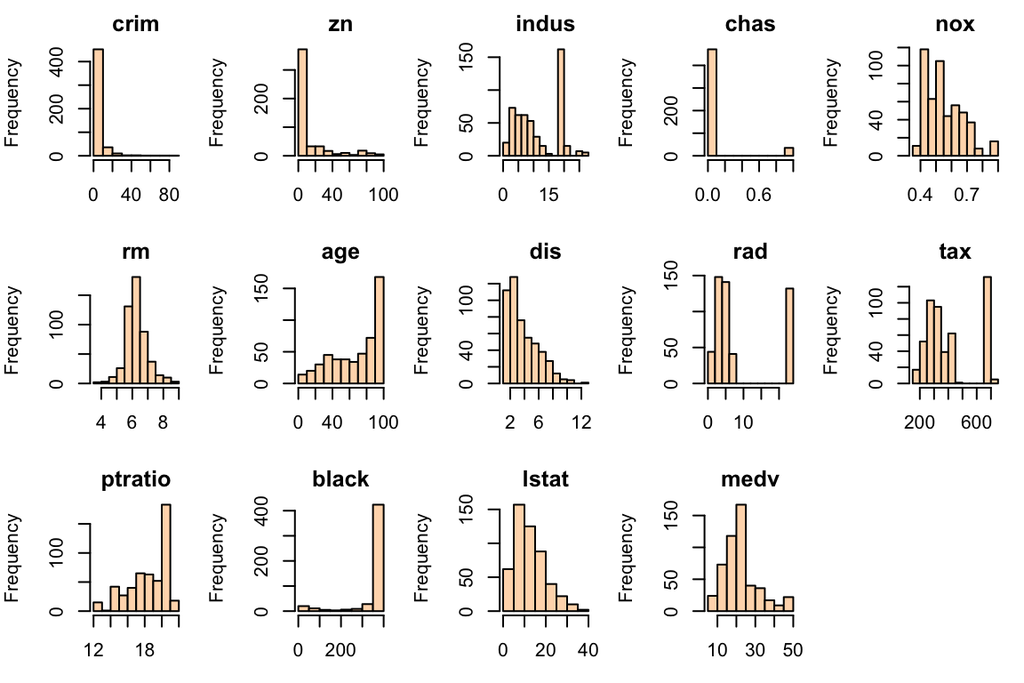

```r
par(mfrow = c(3, 5))
par(mar = c(3, 4, 2, 1))
for(i in 1:ncol(Boston)) hist(Boston[,i], main = colnames(Boston)[i], xlab = "", col = "peachpuff")
par(mfrow = c(1, 1))
```

Clearly there are a lot of irregularities in the distribution of the data. Specifically, many of the marginal distributions are seriously skewed and even multimodal. Hence, no methods assuming normality or near normality of the data should be employed here. Let us next draw a correlation plot to assess the linear dependencies between the variables.

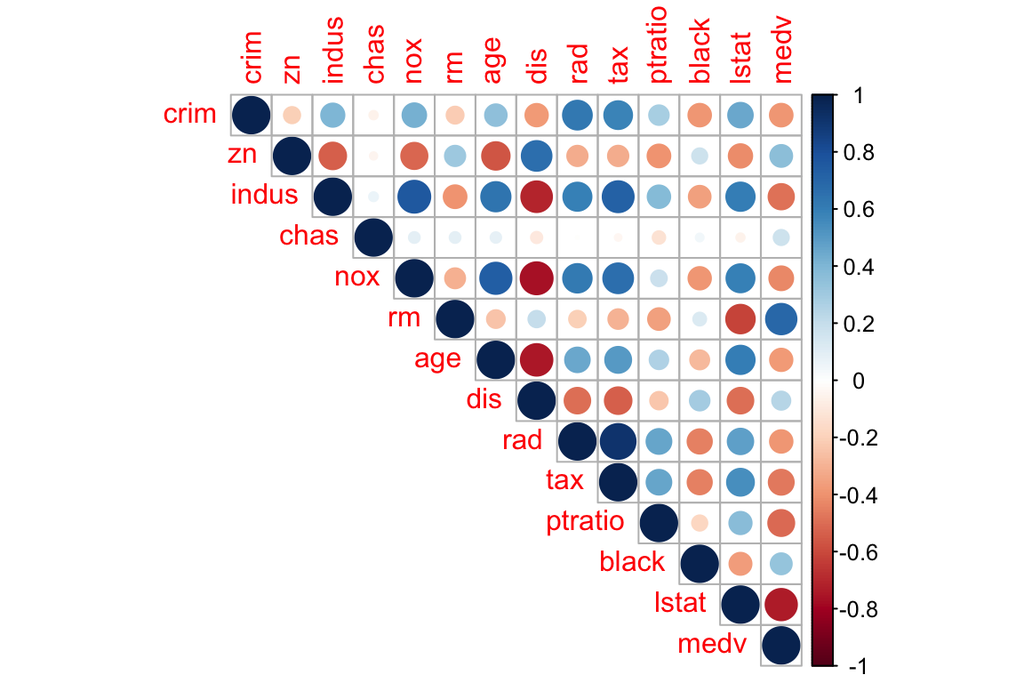

```r
library(corrplot)
cor_matrix <- cor(Boston)
corrplot(cor_matrix, method = "circle", type = "upper")
```

There are multiple strong, both positive and negative, correlations between many of the variables suggesting the variables do indeed have some explanatory power over each other. Below we print out the five largest positive and negative correlations in the data.

```r
print_largest_correlations <- function(data, how_many = 5, negative = FALSE, digits = 2) {
  cm <- cor(data); diag(cm) <- NA; n <- ncol(cm)
  if(how_many > n * (n - 1) / 2) how_many <- n * (n - 1) / 2
  cm_order <- order(cm[upper.tri(cm)])
  largest <- ifelse(rep(negative, how_many), cm_order[1:how_many], rev(cm_order)[1:how_many])
  strings <- c(); cors <- c()
  count <- 1
  for(j in 1:n) {
    for(i in 1:n) {
      if(i >= j) next
      if(count %in% largest) {
        cors <- c(cors, cor(data[,i], data[,j]))
        strings <- c(strings, paste0("cor(", colnames(data)[i], ", ", colnames(data)[j], ") = ",
                   round(cors[length(cors)], digits), "\n"))
      }
      count <- count + 1
    }
  }
  strings <- strings[order(cors, decreasing = !negative)]
  if(!negative) cat("Largest positive correlations: \n") else cat("Largest negative correlations: \n")
  for(i in 1:length(strings)) cat(strings[i])
  cat("\n")
}
```

```r
print_largest_correlations(Boston)
```

```
## Largest positive correlations:
## cor(rad, tax) = 0.91
## cor(indus, nox) = 0.76
## cor(nox, age) = 0.73
## cor(indus, tax) = 0.72
## cor(rm, medv) = 0.7
```

```r
print_largest_correlations(Boston, negative = TRUE)
```

```
## Largest negative correlations:
## cor(nox, dis) = -0.77
## cor(age, dis) = -0.75
## cor(lstat, medv) = -0.74
## cor(indus, dis) = -0.71
## cor(rm, lstat) = -0.61
```

So we have established there to be some linear dependencies between the variables in the data, but what about non-linear dependencies? We may try to visually assess any non-linear dependencies by means of a pair plot (plotted below).

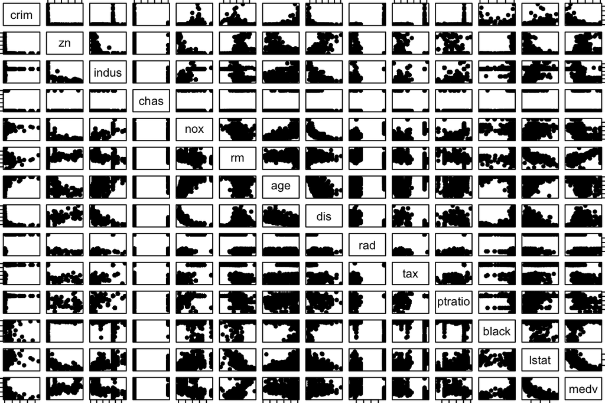

```r
pairs(Boston, gap = 0.5, oma = c(0, 0, 0, 0), pch = 20)
```

Visual assessment doesn’t immediately reveal us any strong dependencies in addition to those linear enough for to result in correlations with high absolute values. However, some dependencies for which the correlations seemed high seem to exhibit significant non-linearities (see e.g. the relationship between `nox` and `dis`) and naive linear models might not be the best approach to model the dependencies in this data.

Before diving to model fitting and further analysis, we shall do some preparations for our data. First we scale the data to have zero mean and unit variance.

```r
boston_scaled <- data.frame(scale(Boston))
summary(boston_scaled)
```

```
##       crim                 zn               indus              chas
##  Min.   :-0.419367   Min.   :-0.48724   Min.   :-1.5563   Min.   :-0.2723
##  1st Qu.:-0.410563   1st Qu.:-0.48724   1st Qu.:-0.8668   1st Qu.:-0.2723
##  Median :-0.390280   Median :-0.48724   Median :-0.2109   Median :-0.2723
##  Mean   : 0.000000   Mean   : 0.00000   Mean   : 0.0000   Mean   : 0.0000
##  3rd Qu.: 0.007389   3rd Qu.: 0.04872   3rd Qu.: 1.0150   3rd Qu.:-0.2723
##  Max.   : 9.924110   Max.   : 3.80047   Max.   : 2.4202   Max.   : 3.6648
##       nox                rm               age               dis
##  Min.   :-1.4644   Min.   :-3.8764   Min.   :-2.3331   Min.   :-1.2658
##  1st Qu.:-0.9121   1st Qu.:-0.5681   1st Qu.:-0.8366   1st Qu.:-0.8049
##  Median :-0.1441   Median :-0.1084   Median : 0.3171   Median :-0.2790
##  Mean   : 0.0000   Mean   : 0.0000   Mean   : 0.0000   Mean   : 0.0000
##  3rd Qu.: 0.5981   3rd Qu.: 0.4823   3rd Qu.: 0.9059   3rd Qu.: 0.6617
##  Max.   : 2.7296   Max.   : 3.5515   Max.   : 1.1164   Max.   : 3.9566
##       rad               tax             ptratio            black
##  Min.   :-0.9819   Min.   :-1.3127   Min.   :-2.7047   Min.   :-3.9033
##  1st Qu.:-0.6373   1st Qu.:-0.7668   1st Qu.:-0.4876   1st Qu.: 0.2049
##  Median :-0.5225   Median :-0.4642   Median : 0.2746   Median : 0.3808
##  Mean   : 0.0000   Mean   : 0.0000   Mean   : 0.0000   Mean   : 0.0000
##  3rd Qu.: 1.6596   3rd Qu.: 1.5294   3rd Qu.: 0.8058   3rd Qu.: 0.4332
##  Max.   : 1.6596   Max.   : 1.7964   Max.   : 1.6372   Max.   : 0.4406
##      lstat              medv
##  Min.   :-1.5296   Min.   :-1.9063
##  1st Qu.:-0.7986   1st Qu.:-0.5989
##  Median :-0.1811   Median :-0.1449
##  Mean   : 0.0000   Mean   : 0.0000
##  3rd Qu.: 0.6024   3rd Qu.: 0.2683
##  Max.   : 3.5453   Max.   : 2.9865
```

We shall also replace the numerical variable `crim` (crime rates) with a categorical counterpart with four levels (“low”, “med_low”, “med_high”, “high”) using interquartiles as break points.

```r
bins <- quantile(boston_scaled$crim)
crime <- cut(boston_scaled$crim, breaks = bins, include.lowest = TRUE,
             labels = c("low", "med_low", "med_high", "high"))
boston_scaled$crim <- crime
```

We then divide the data to a train and test sets with a random 80/20 split.

```r
# Random 80/20 split:
# (floor(n * 0.8) returns an integer -> less ambiguous than n * 0.8, also
#  'sample.int' slightly more efficient and less ambiguous than 'sample')
n <- nrow(boston_scaled)
ind <- sample.int(n,  size = floor(n * 0.8))
train <- data.frame(boston_scaled[ind,], stringsAsFactors = TRUE)
test <- data.frame(boston_scaled[-ind,], stringsAsFactors = TRUE)

# Save the correct classes from test data (just in case)...
correct_classes <- test$crim

# ...after which remove the crime variable from test data:
test$crim <- NULL
```

Then, although we have established the non-normality of the variables, we shall use something that assumes the data to follow a multinormal distribution, because why not! Linear discriminant analysis it is (LDA).

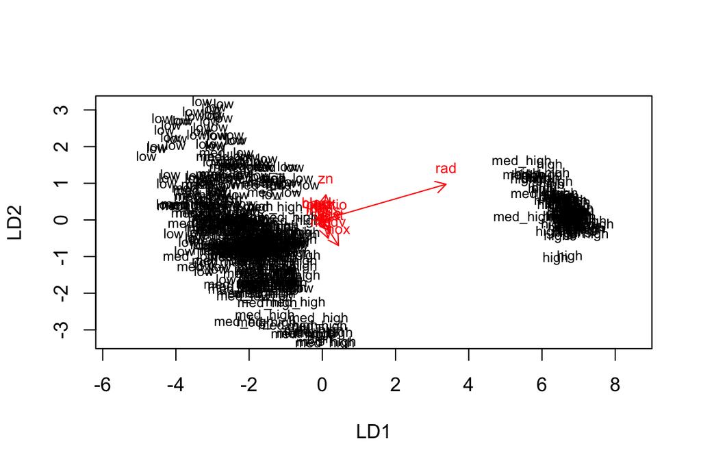

```r
# LDA model
lda.fit <- MASS::lda(crim ~ ., data = train)

# The function for LDA biplot arrows
lda.arrows <- function(x, myscale = 1, arrow_heads = 0.1, color = "red", tex = 0.75, choices = c(1,2)){
  heads <- coef(x)
  arrows(x0 = 0, y0 = 0,
         x1 = myscale * heads[,choices[1]],
         y1 = myscale * heads[,choices[2]], col=color, length = arrow_heads)
  text(myscale * heads[,choices], labels = row.names(heads),
       cex = tex, col=color, pos=3)
}

# Target classes as numeric
classes <- as.numeric(train$crime)

# Plot the LDA biplot
plot(lda.fit, dimen = 2)
lda.arrows(lda.fit, myscale = 1)
```

```r
lda.pred <- predict(lda.fit, newdata = test)
table(correct = correct_classes, predicted = lda.pred$class)
```

```
##           predicted
## correct    low med_low med_high high
##   low       16       8        2    0
##   med_low    6      16        8    0
##   med_high   0       6       12    2
##   high       0       0        0   26
```

However, perhaps there are other methods that could perform even better? To that end, let us compare the results attained with LDA to those attained by means of k-means algorithm. For one, k-means algorithm does not assume the variables to follow a multivariate normal distribution so perhaps it performs better than LDA? Let us first reload and scale the data, take quick look at the distances between observations in the data, and then run the k-means algorithm first with four clusters.

```r
# Reload tha original data
library(MASS)
data("Boston")

# Scale the data
boston_scaled <- data.frame(scale(Boston))

# Calculate the (Euclidean) distances of observations in the data
dist <- dist(Boston)
summary(dist)
```

```
##    Min. 1st Qu.  Median    Mean 3rd Qu.    Max.
##   1.119  85.624 170.539 226.315 371.950 626.047
```

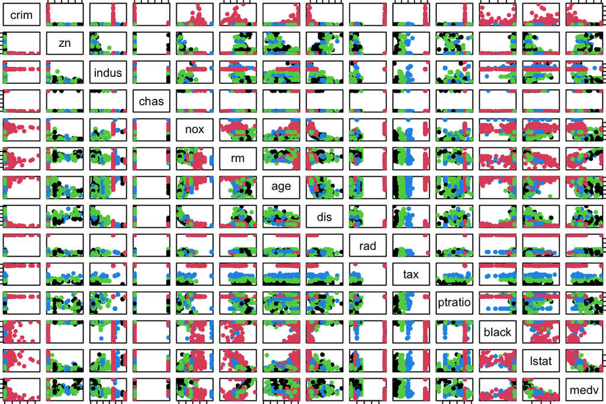

```r
# Set random seed
set.seed(42)

# Run the k-means algorithm
km <- kmeans(Boston, centers = 4)

# Visualize the results with a pairplot
pairs(Boston, col = km$cluster, gap = 0.5, oma = c(0, 0, 0, 0), pch = 20)
```

For some variables-pairs the four clusters seem to do a great job at differentiating the data (as depicted by the above pairplot), whereas for others the clusters are less clear. To that end, let us assess how the total of within cluster sum of squares (WCSS) behaves as a function of the number of clusters.

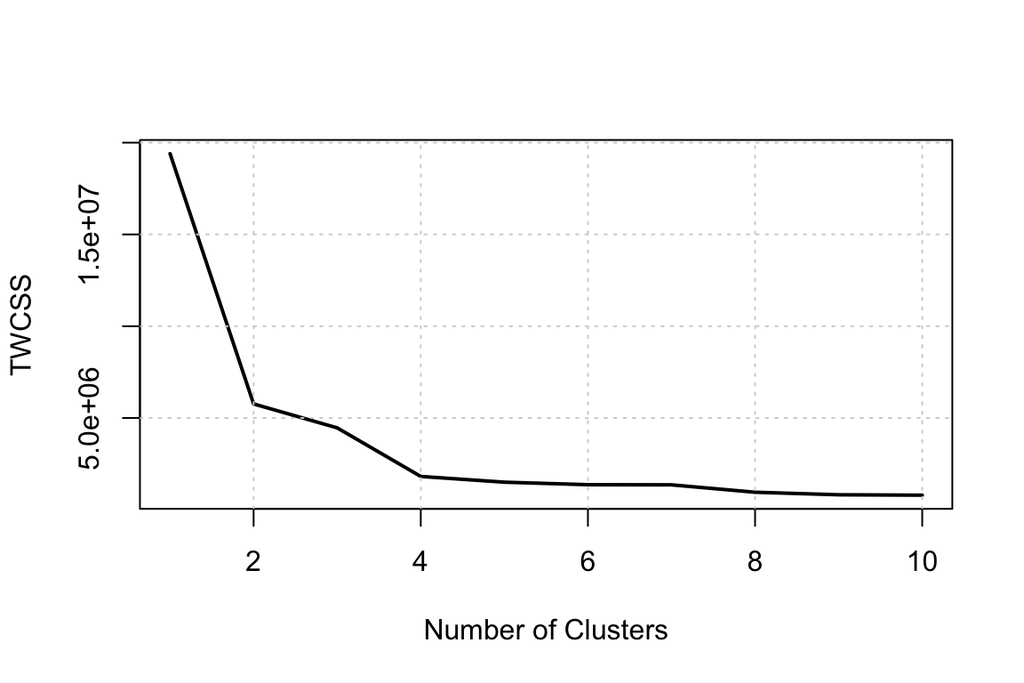

```r
# Set random seed
set.seed(42)

# Set the max number of clusters
k_max <- 10

# Calculate the total within sum of squares for every number of clusters
TWCSS <- sapply(1:k_max, function(k){kmeans(Boston, k)$tot.withinss})

# Visualize the results
plot(x = 1:k_max, y = TWCSS, type = "l", xlab = "Number of Clusters", lwd = 2)
grid()
```

The most drastic changes in TWCSS happen when two clusters are included. After that the decrease in TWCSS is still significant up to the inclusion of four clusters after which any gains are more or less marginal. The originally used four clusters might then be pretty close to the optimal number of clusters.

Although we didn’t really get to do comparisons of the LDA and k-means algorithm in the end, both approaches seemed to be able to fit the data quite well and interesting insights to the data could most probably be drawn with either method.